# Regression_OLS_Assumption_FEVdata

## Setup

Load library, set figure size

```r
rm(list=ls()) # clear all workspace, very important to do this to refresh
knitr::opts_chunk$set(echo = TRUE)
knitr::opts_chunk$set(fig.width=4.5, fig.height=4.5)
library(tidyverse)
library(epitools)
library(htmlTable)
library(autoReg)
library(labelled)
```

### Data size for simulation and custom function to format table names

```r
N = 200

funcColNames <- function(d){
  colnames(d)[colnames(d) == "term"] <- "Coefficient"
  colnames(d)[colnames(d) == "conf.low"] <- "ConfInt.Lower"
  colnames(d)[colnames(d) == "conf.high"] <- "ConfInt.Higher"
  return(d)
}
# Make shorter variables names
funcColNames2 <- function(d){
  colnames(d)[colnames(d) == "term"] <- "Coef"
  colnames(d)[colnames(d) == "conf.low"] <- "CI.Lower"
  colnames(d)[colnames(d) == "conf.high"] <- "CI.Higher"
  d <- d %>% select(-c(p.value, statistic))
  return(d)
}
```

## Real data to check the assumptions

FEV (Forced Expiration Volume) study, can be download from many sources

```r
url <- "http://www.emersonstatistics.com/datasets/fev.txt"
download.file(url, "fev.txt" )
dat <- read.csv("https://github.com/walkabilly/chep801_usask/raw/main/fev.txt", sep="")

# Describe data
glimpse(dat)
```

```
## Rows: 654
## Columns: 7
## $ seqnbr <int> 1, 2, 3, 4, 5, 6, 7, 8, 9, 10, 11, 12, 13, 14, 15, 16, 17, 18, …
## $ subjid <int> 301, 451, 501, 642, 901, 1701, 1752, 1753, 1901, 1951, 1952, 20…
## $ age    <int> 9, 8, 7, 9, 9, 8, 6, 6, 8, 9, 6, 8, 8, 8, 8, 7, 5, 6, 9, 9, 5, …
## $ fev    <dbl> 1.708, 1.724, 1.720, 1.558, 1.895, 2.336, 1.919, 1.415, 1.987, …
## $ height <dbl> 57.0, 67.5, 54.5, 53.0, 57.0, 61.0, 58.0, 56.0, 58.5, 60.0, 53.…
## $ sex    <int> 2, 2, 2, 1, 1, 2, 2, 2, 2, 2, 2, 1, 2, 1, 1, 1, 1, 2, 1, 1, 2, …
## $ smoke  <int> 2, 2, 2, 2, 2, 2, 2, 2, 2, 2, 2, 2, 2, 2, 2, 2, 2, 2, 2, 2, 2, …
```

```r
# Make categorical varaibles out of characters
dat$sex <- factor(dat$sex)
levels(dat$sex) = c("Female", "Male")
table(dat$sex)
```

```
##
## Female   Male
##    336    318
```

```r
dat$smoke <- factor(dat$smoke)
levels(dat$smoke) <- c("Smoker", "Non-smoker")
table(dat$smoke)
```

```
##
##     Smoker Non-smoker
##         65        589
```

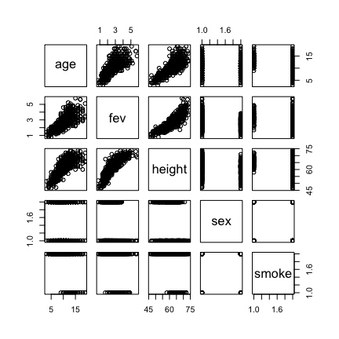

```r
pairs(dat %>%  select(-c("seqnbr", subjid)))
```

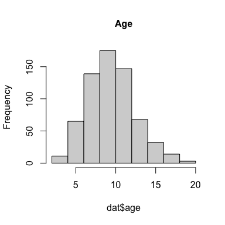

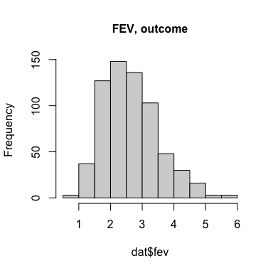

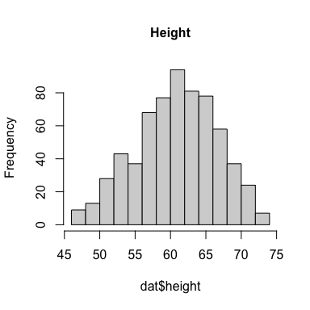

```r
# Distribution of continuous outcomes
hist(dat$age, main = "Age", cex.main = 1)
hist(dat$fev, main = "FEV, outcome", cex.main = 1)
hist(dat$height, main = "Height", cex.main = 1)
```

### Descriptive plots - xy age and fev

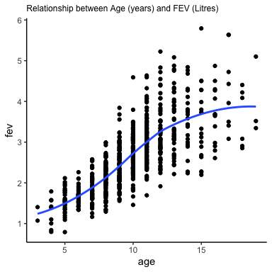

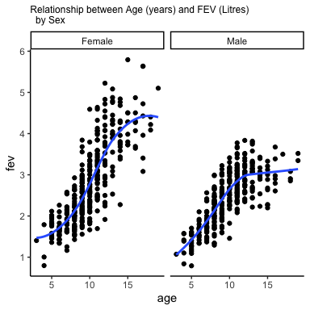

```r
ggplot(dat, aes(x= age, y = fev)) +
  geom_point() +
  theme_classic() +
  ggtitle("Relationship between Age (years) and FEV (Litres)") +
  theme(plot.title = element_text(size = 9)) +
   geom_smooth(se=FALSE)
ggplot(dat, aes(x= age, y = fev)) +
  geom_point() +
  theme_classic() +
  ggtitle("Relationship between Age (years) and FEV (Litres) \n  by Sex") +
  facet_wrap(~sex) +
  theme(plot.title = element_text(size = 9)) +
   geom_smooth(se=FALSE)
```

### Descriptive plots - height and fev

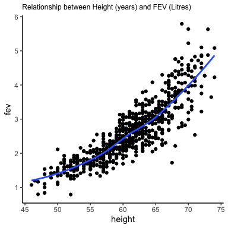

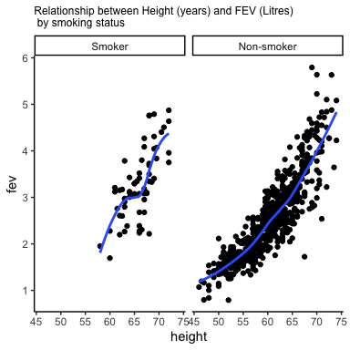

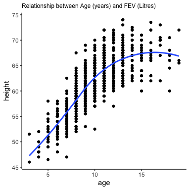

```r
ggplot(dat, aes(x= height, y = fev)) +
  geom_point() +
  theme_classic() +
  ggtitle("Relationship between Height (years) and FEV (Litres)")+
  theme(plot.title = element_text(size = 9)) +
   geom_smooth(se=FALSE)
ggplot(dat, aes(x= height, y = fev)) +
  geom_point() +
  theme_classic() +
  ggtitle("Relationship between Height (years) and FEV (Litres) \n by smoking status") +
  facet_wrap(~smoke)+
  theme(plot.title = element_text(size = 9)) +
   geom_smooth(se=FALSE)
ggplot(dat, aes(x= age, y = height)) +
  geom_point() +
  theme_classic() +
  ggtitle("Relationship between Age (years) and FEV (Litres)")+
  theme(plot.title = element_text(size = 9)) +
   geom_smooth(se=FALSE)
```

```r
ggplot(dat, aes(sex, fev)) + geom_boxplot() + theme_classic() + ggtitle("FEV by sex")
ggplot(dat, aes(smoke, fev)) + geom_boxplot() + theme_classic() + ggtitle("FEV by smoking status")

knitr::kable(table(dat$sex), digits = 2, caption = "Results: Linear model ")
```

Results: Linear model

| Var1 | Freq |
| --- | --- |
| Female | 336 |
| Male | 318 |

```r
knitr::kable(table(dat$smoke), digits = 2, caption = "Results: Linear model ")
```

Results: Linear model

| Var1 | Freq |
| --- | --- |
| Smoker | 65 |
| Non-smoker | 589 |

[figure not shown]

[figure not shown]

### Plot all varaibles at once, execpt person IDs

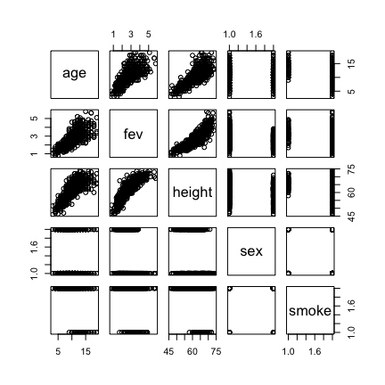

```r
dat %>% select(-c(seqnbr, subjid)) %>% pairs
```

## Exploratory regression analysis,

#### single variable regression between FEV and each covariate

#### remember though, just looking at coefficients only is not as imformative as x-y plots above

```r
independentVariables <- c("age", "height", "smoke", "sex")
independentVariablesData<- dat[, independentVariables]
fitList <- lapply(1:ncol(independentVariablesData), function(x) lm(dat$fev ~ independentVariablesData[,x]))

# extract just coefficients
sapply(fitList, coef)
```

```
##                                    [,1]       [,2]       [,3]       [,4]
## (Intercept)                   0.4316481 -5.4326788  3.2768615  2.8124464
## independentVariablesData[, x] 0.2220410  0.1319756 -0.7107189 -0.3612766
```

```r
fit=lm(fev~age+sex+height+smoke,data=dat)

#fit=lm(fev~age*sex*height*smoke,data=dat)
autoReg(fit,uni=TRUE, threshold=0.2) %>% myft()
```

```
## Usage of empty symbol '' with footnote should not happen,
## use `add_footer_lines()` instead, it does not require any symbol.
## This usage will be forbidden in the next release. Please, wait for 10 seconds!
```

[output not shown]

```r
final=step(fit,trace=0)
summary(final)
```

```
##
## Call:
## lm(formula = fev ~ age + sex + height + smoke, data = dat)
##
## Residuals:
##      Min       1Q   Median       3Q      Max
## -1.37656 -0.25033  0.00894  0.25588  1.92047
##
## Coefficients:
##                  Estimate Std. Error t value Pr(>|t|)
## (Intercept)     -4.387117   0.239799 -18.295  < 2e-16 ***
## age              0.065509   0.009489   6.904 1.21e-11 ***
## sexMale         -0.157103   0.033207  -4.731 2.74e-06 ***
## height           0.104199   0.004758  21.901  < 2e-16 ***
## smokeNon-smoker  0.087246   0.059254   1.472    0.141
## ---
## Signif. codes:  0 '***' 0.001 '**' 0.01 '*' 0.05 '.' 0.1 ' ' 1
##
## Residual standard error: 0.4122 on 649 degrees of freedom
## Multiple R-squared:  0.7754, Adjusted R-squared:  0.774
## F-statistic:   560 on 4 and 649 DF,  p-value: < 2.2e-16
```

#### Multivariable regression

Our model of interest is:
$$E[Y_{fev}] =
\alpha + \beta_{age}*age + \beta_{height}*height +
\beta_{smoking}*smoking + \beta_{sex}*sex$$

```r
fit=lm(fev~age+sex+height+smoke,data=dat)
datPlot <- data.frame(dat, fitted =  fit$fitted.values, residual = fit$residuals)
```

### Our FEV model, for now throw everything, Exposure of interesting smoking yes/no

#### As usual, be sure to consult with DAF for real analysis

#### No interaction term for now

### Assumption 1 - Lienarity of outcome with fitted values (or x if univariate model)

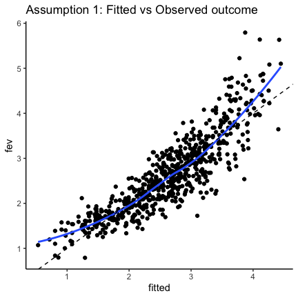

```r
ggplot(data = datPlot, aes(y = fev, x = fitted)) +
  geom_point() +
  theme_classic() +
  ggtitle("Assumption 1: Fitted vs Observed outcome") +
  geom_smooth(se = FALSE) +
  geom_abline(slope = 1,linetype = "dashed")
```

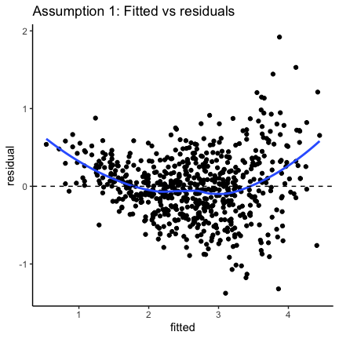

```r
ggplot(data = datPlot, aes(y = residual, x = fitted)) +
  geom_point() +
  theme_classic() +
  ggtitle("Assumption 1: Fitted vs residuals") +
  geom_smooth(se = FALSE) +
  geom_hline(yintercept = 0, linetype = "dashed")
```

### Assumption 1 - plot by Sex and Smoking

#### Besure though, smokign is our exposure of interest, so we cannot subset data by smoke

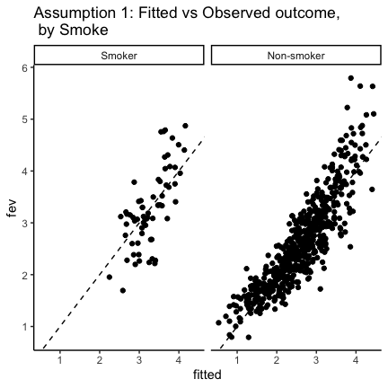

```r
ggplot(data = datPlot, aes(y = fev, x = fitted)) +
  geom_point() +
  theme_classic() +
  facet_wrap(~smoke) +
  ggtitle("Assumption 1: Fitted vs Observed outcome, \n by Smoke")+
  geom_abline(slope = 1,linetype = "dashed")
```

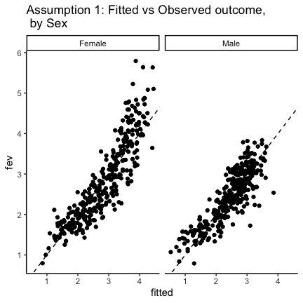

```r
ggplot(data = datPlot, aes(y = fev, x = fitted)) +
  geom_point() +
  theme_classic() +
  facet_wrap(~sex) +
  ggtitle("Assumption 1: Fitted vs Observed outcome, \n by Sex")+
  geom_abline(slope = 1,linetype = "dashed")
```

### Assumption 1 - Perhaps, quadratic term in the regression model, since we saw that FEV is non-linear with age and height? This cold lead to residual confounding by age and height.

#### Abter adding quadratic term for age and height, the association of fitted and observed FEV look linear **BUT**, the interpretation of age and height are no longer linear (quadratic term added), and there is a larger disagreement at higher values of fitted and observed.

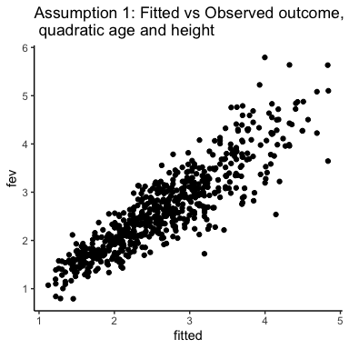

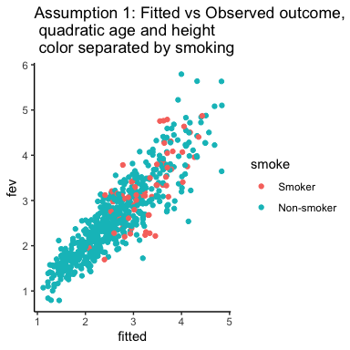

[figure not shown]

```r
dat$age2 <- dat$age*dat$age
dat$height2 <- dat$height*dat$height
fit=lm(fev~age +age2 +sex+height + height2+smoke,data=dat)
datPlot_Q <- data.frame(dat, fitted =  fit$fitted.values, residual = fit$residuals)

ggplot(data = datPlot_Q, aes(y = fev, x = fitted)) +
  geom_point() +
  theme_classic() +
  ggtitle("Assumption 1: Fitted vs Observed outcome, \n quadratic age and height")


ggplot(data = datPlot_Q, aes(y = fev, x = fitted, color = smoke)) +
  geom_point() +
  theme_classic() +
  ggtitle("Assumption 1: Fitted vs Observed outcome, \n quadratic age and height \n color separated by smoking ")

ggplot(data = datPlot, aes(y = fev, x = fitted)) +
  geom_point() +
  theme_classic() +
  ggtitle("Assumption 1: Fitted vs Observed outcome \ Original model ")
```

### Assumption 2 - Independence of errors (residuals)

#### Assumption 3 - Constant dispersion of residuals across the value of fitted values (if multiple regression), or x (if univariate model)

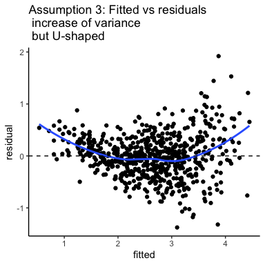

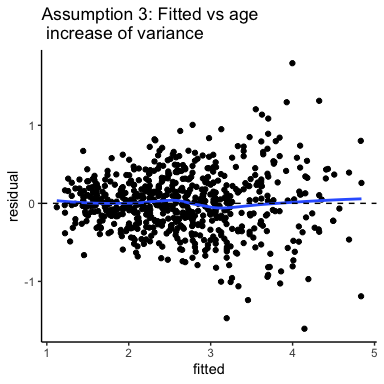

```r
ggplot(data = datPlot, aes(y = residual, x = fitted)) +
  geom_point() +
  theme_classic() +
  ggtitle("Assumption 3: Fitted vs residuals \n increase of variance \n but U-shaped") +
  geom_smooth(se = FALSE) +
  geom_hline(yintercept = 0, linetype = "dashed")
ggplot(data = datPlot_Q, aes(y = residual, x = fitted)) +
  geom_point() +
  theme_classic() +
  ggtitle("Assumption 3: Fitted vs age \n increase of variance") +
    geom_smooth(se = FALSE) +
  geom_hline(yintercept = 0, linetype = "dashed")
```

#### Assumption 3 - Constant dispersion of residuals across the value of fitted values (if multiple regression), or x (if univariate model)

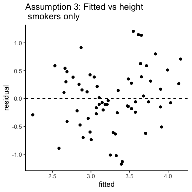

```r
ggplot(data = datPlot[datPlot$smoke == "Smoker", ], aes(y = residual, x = fitted)) +
  geom_point() +
  theme_classic() +
  ggtitle("Assumption 3: Fitted vs height \n smokers only") +
  geom_hline(yintercept = 0, linetype = "dashed")
```

#### Assumption 3 - Constant dispersion of residuals across the value of fitted values (if multiple regression), or x (if univariate model)

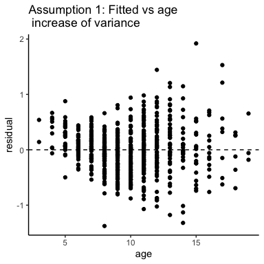

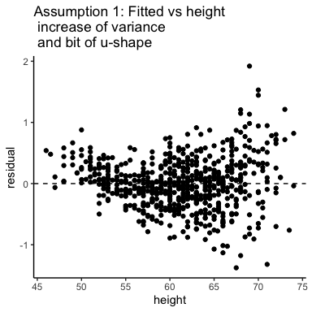

```r
ggplot(data = datPlot, aes(y = residual, x = age)) +
  geom_point() +
  theme_classic() +
  ggtitle("Assumption 1: Fitted vs age \n increase of variance") +
  geom_hline(yintercept = 0, linetype = "dashed")

ggplot(data = datPlot, aes(y = residual, x = height)) +
  geom_point() +
  theme_classic() +
  ggtitle("Assumption 1: Fitted vs height \n increase of variance \n and bit of u-shape") +
  geom_hline(yintercept = 0, linetype = "dashed")
```

### Assumption 4 - Resisuals are normally distributed

#### We typically do not get very normal distribution of residuals

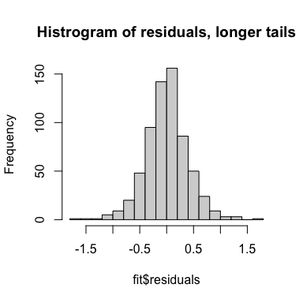

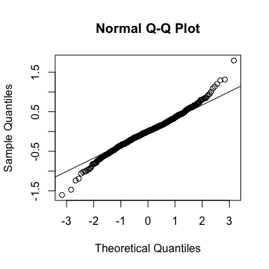

```r
hist(fit$residuals, main = "Histrogram of residuals, longer tails", breaks = 20)
qqnorm(fit$residuals)
qqline(fit$residuals)
```

### Assumptions - Summary of residual diagnosis

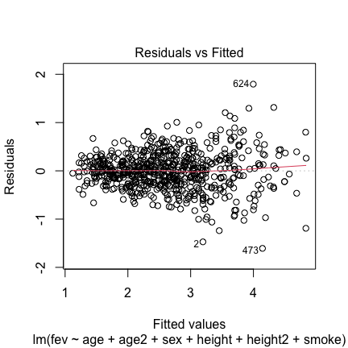

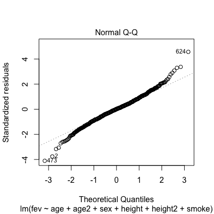

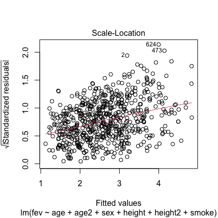

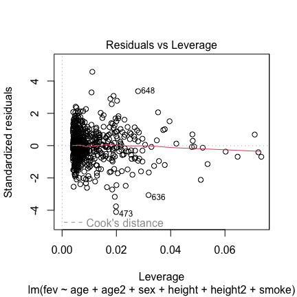

```r
plot(fit)
```